# racoon - CLIP processing report

Melina Klostermann

21 September, 2023

# 1 Overview over raccon steps

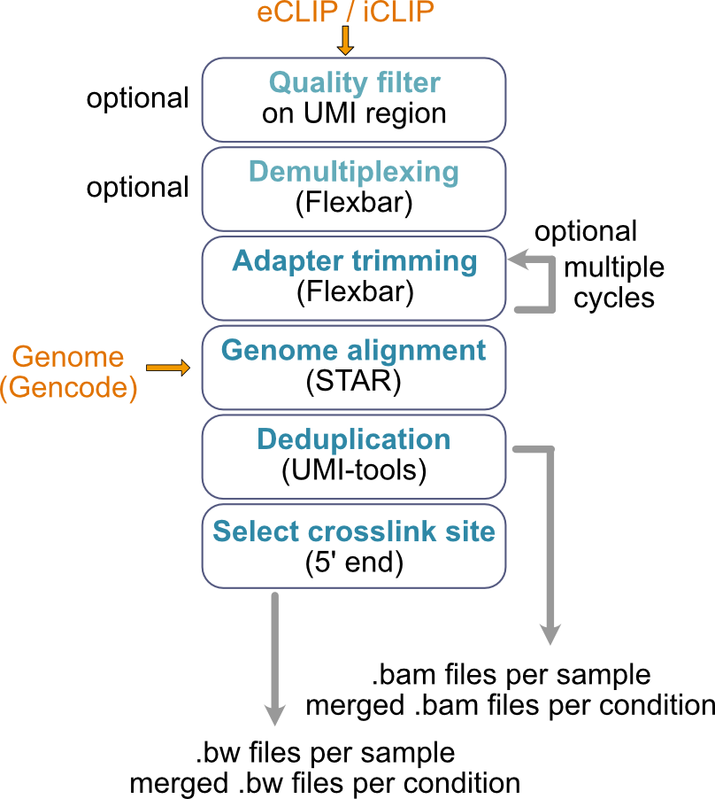

# 2 Configurations

Here is a summary off the settings you chose for this analysis.

[output not shown]

## 2.1 Input files

[output not shown]

## 2.2 Options

|  | Option |
| --- | --- |
| demuliplex | False |
| adapter_trimming | FALSE |
| quality_filter_barcodes | FALSE |
| encode | False |
| deduplicate | FALSE |

## 2.3 Barcode settings

|  | Setting |
| --- | --- |
| barcodeLength | 0 |
| minBaseQuality | 10 |
| umi1_len | 0 |
| umi2_len | 0 |
| exp_barcode_len | 0 |
| samples | U2AF2_HeLa_s1 U2AF2_HeLa_s2 U2AF2_HeLa_s3 |
| encode | False |
| encode_umi_length | 0 |

## 2.4 Read filter

|  | Setting |
| --- | --- |
| min_read_length | 15 |

## 2.5 Alignment setting (STAR)

|  | Setting |
| --- | --- |
| read_length | 150 |
| outFilterMismatchNoverReadLmax | 0.04 |
| outFilterMismatchNmax | 999 |
| outFilterMultimapNmax | 1 |
| outReadsUnmapped | Fastx |
| outSJfilterReads | Unique |
| moreSTARParameters |  |

## 2.6 Experiemnt groups

| Group | Sample |
| --- | --- |
| U2AF2_HeLa | U2AF2_HeLa_s1 |
| U2AF2_HeLa | U2AF2_HeLa_s2 |
| U2AF2_HeLa | U2AF2_HeLa_s3 |

# 3 Quality control of raw files

Initial quality control of the raw sequencing file is performed with FastQC. Here you can see the sequencing quality and contend per base.

## 3.1 Quality scores across all bases

### U2AF2_HeLa_s1

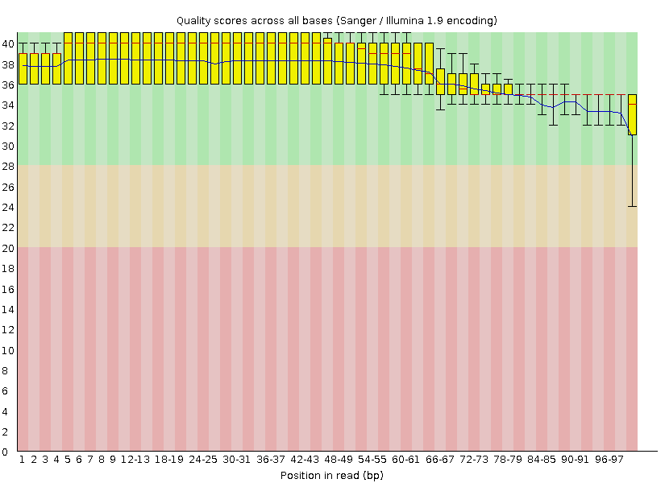

### U2AF2_HeLa_s2

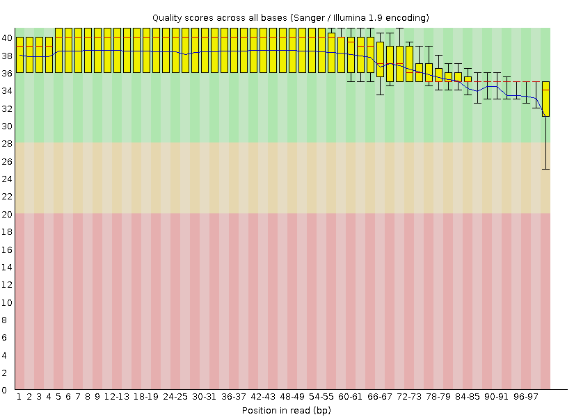

### U2AF2_HeLa_s3

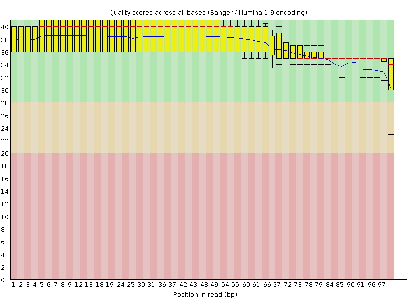

## 3.2 Sequence content across all bases

### U2AF2_HeLa_s1

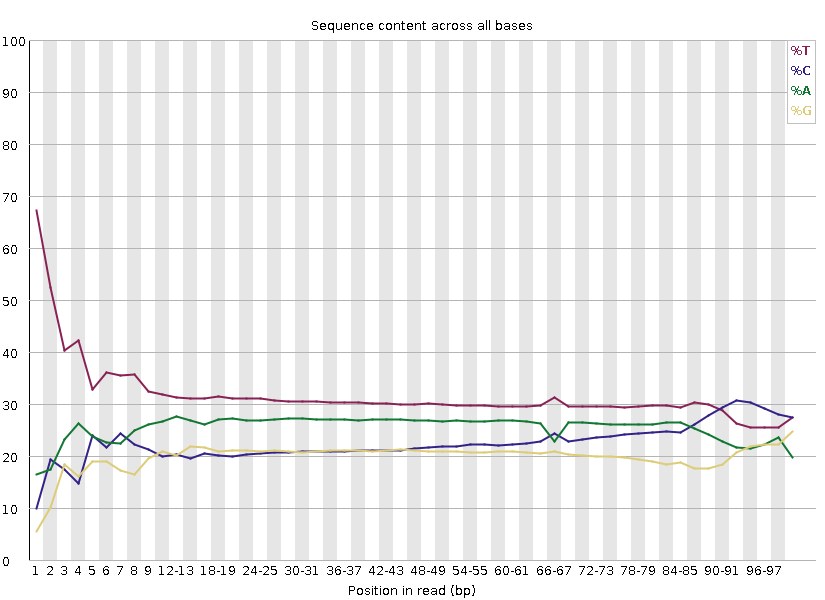

### U2AF2_HeLa_s2

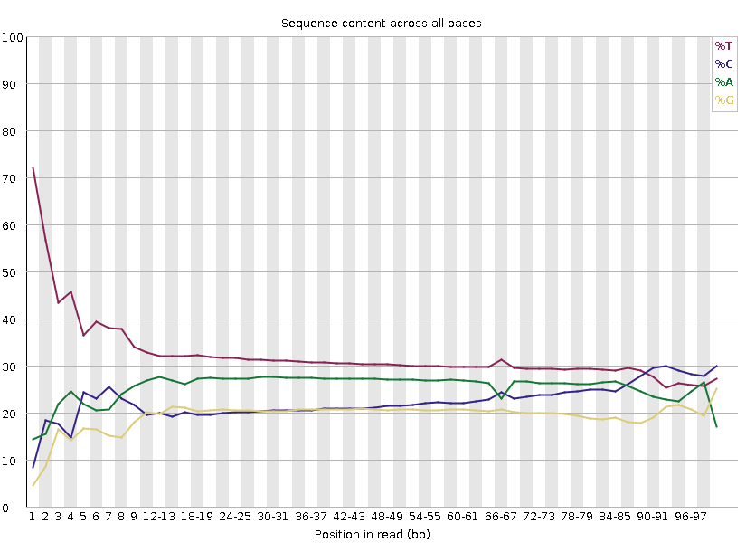

### U2AF2_HeLa_s3

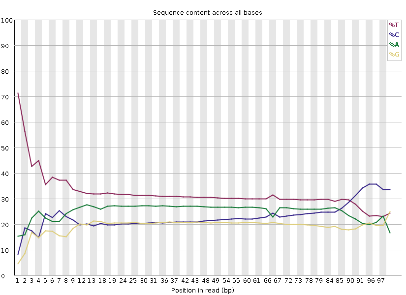

# 4 Adapter trimming

## 4.1 Adapter Content before trimming

Position of adapters found in the reads. If adapters are found early in the reads, this points to overdigestion of the samples.

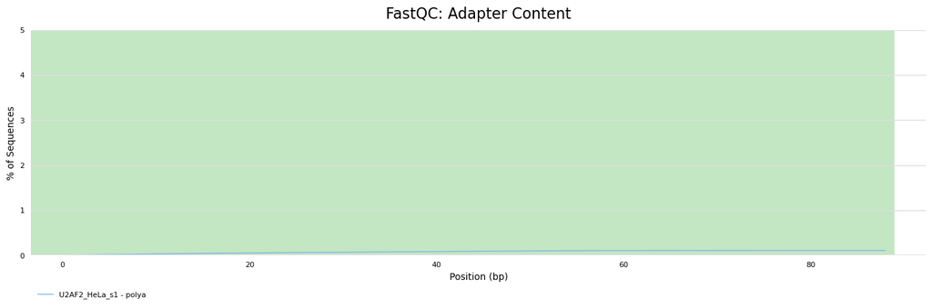

## 4.2 Adapter content after trimming

No trimming was performed.

# 5 Mapping

The genome annotation is indexed with STAR –runMode genomeGenerate. Then the merged file of the chimeric reads is aligned to the genome annotation with STAR –runMode alignReads. For STAR settings see configurations. Obtained bam files are indexed with samtools index.

|  | U2AF2_HeLa_s1 | U2AF2_HeLa_s2 | U2AF2_HeLa_s3 |
| --- | --- | --- | --- |
| Number of input reads | 35351663 | 15189366 | 15500883 |
| Uniquely mapped reads number | 33888094 | 14537482 | 14841024 |
| Uniquely mapped reads % | 95.86% | 95.71% | 95.74% |
| Number of reads mapped to multiple loci | 0 | 0 | 0 |
| % of reads mapped to multiple loci | 0.00% | 0.00% | 0.00% |
| Number of reads mapped to too many loci | 1091414 | 465516 | 474410 |
| % of reads mapped to too many loci | 3.09% | 3.06% | 3.06% |
| Number of reads unmapped: too many mismatches | 345266 | 174301 | 173588 |
| % of reads unmapped: too many mismatches | 0.98% | 1.15% | 1.12% |
| Number of reads unmapped: too short | 26767 | 12030 | 11811 |
| % of reads unmapped: too short | 0.08% | 0.08% | 0.08% |
| Number of reads unmapped: other | 122 | 37 | 50 |
| % of reads unmapped: other | 0.00% | 0.00% | 0.00% |

[figure not shown]